# CapStone Milestone Report

Michael G Harpole

2024-01-05

## Read in Data

We have three files containg text from twitter, blog posts and news articles.

```r
library(tidyverse);library(quanteda);library(quanteda.textplots);library(quanteda.textstats)
set.seed(240101)
twitter_data <- read_lines("./en_US/en_US.twitter.txt")
blog_data <- read_lines("./en_US/en_US.blogs.txt")
news_data <- read_lines("./en_US/en_US.news.txt")
```

## Check size of data sets

```r
length_twitter <- length(twitter_data)
length_news <- length(news_data)
length_blog <- length(blog_data)
words_twitter <- sum(str_count(twitter_data))
words_news <- sum(str_count(news_data))
words_blog <- sum(str_count(blog_data))
lenght_summary <- paste(
    "Total Amount of lines in each dataset.\n",
    "Twitter length:\t ",
    format(length_twitter,big.mark=",",scientific=FALSE),
    "\nNews length:\t\t ",
    format(length_news,big.mark=",",scientific=FALSE),
    "\nBlog Length:\t\t",
    format(length_blog,big.mark=",",scientific=FALSE),
    "\n"
    )
Word_summary <- paste(
   "Approximate number of words in each dataset.\n",
    "Twitter length:\t ",
    format(words_twitter,big.mark=",",scientific=FALSE),
    "\nNews length:\t\t ",
    format(words_news,big.mark=",",scientific=FALSE),
    "\nBlog Length:\t\t",
    format(words_blog,big.mark=",",scientific=FALSE)
    )
cat(lenght_summary)
```

Total Amount of lines in each dataset. Twitter length: 2,360,148 News length: 1,010,242 Blog Length: 899,288

```r
cat(Word_summary)
```

[output not shown]

## Tokenize Data

The quanteda R package was utilized to generate word tokens and also remove punctuation, symbols, separators, URL, and english articles.

```r
my_Text_Tokens <- tokens(c(blog_data,twitter_data,news_data),
                         remove_symbols = TRUE,
                         remove_punct = TRUE,
                         remove_numbers = TRUE,
                         remove_separators = TRUE,
                         remove_url =TRUE
                         ) %>%
tokens_tolower() %>%
tokens_remove(stopwords(source = "smart"), padding = FALSE)
```

## Create document-feature matrix

Quanteda was then utilized to generate a document feature matrix to help examine the frequency of each of the words

```r
my_feature_matrix <- dfm(my_Text_Tokens)
```

## Create barplot and a word cloud to examine features

Next a plot of the top 20 words found in the compiled data set were plotted against the frequency of them occurring. Additionally a word cloud was generated to present the data in another manner to can insight of the words utilized.

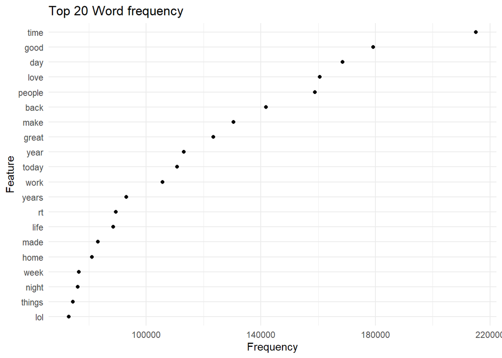

```r
my_feature_matrix %>%
  textstat_frequency(n=20) %>%
  ggplot(aes(x=frequency,y= reorder(feature, frequency))) +
  geom_point() +
  labs(x = "Frequency", y = "Feature")+
  theme_minimal()+
  ggtitle("Top 20 Word frequency")
```

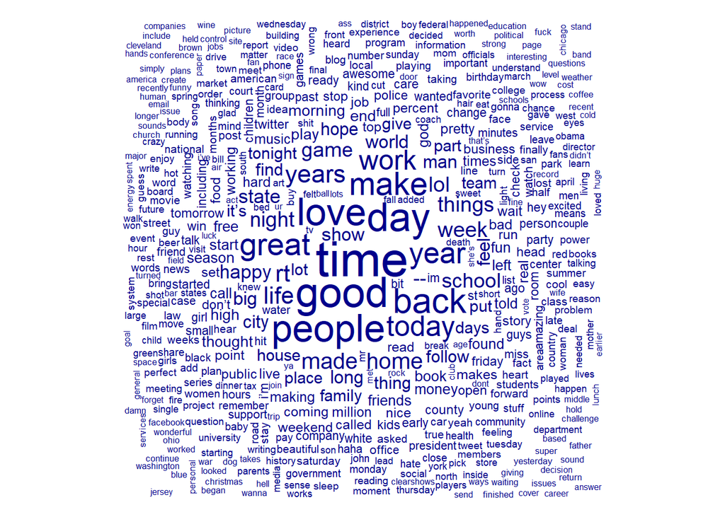

```r
my_feature_matrix %>%
  textplot_wordcloud()
```

The amount of data may be an issue when utilizing the feature matrix for a prediction model. A sampleing of the final feature matrix or of the initial data may be required. The computer utilized to generate this intial analysis had 16 threads and 64 Gb of RAM and the free shiny servers are limited to 1 gb ram.